# Visualise participants against model predictions for stability parameter 0.9

2024-10-10

This code combines participant and model predictions at stability parameter 0.9.

## Correlation to check model fit

This scatter plot is for all three probability settings, for just this value of s.

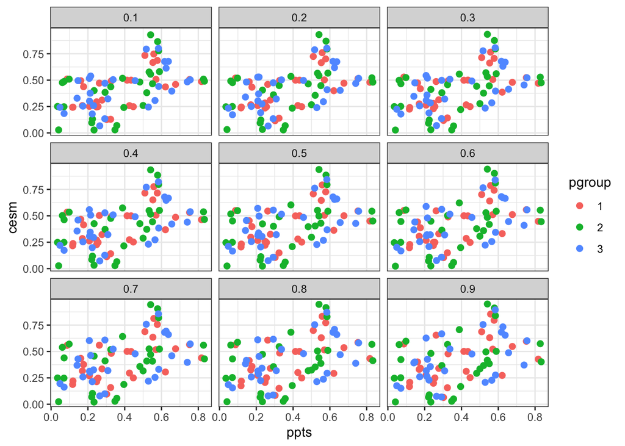

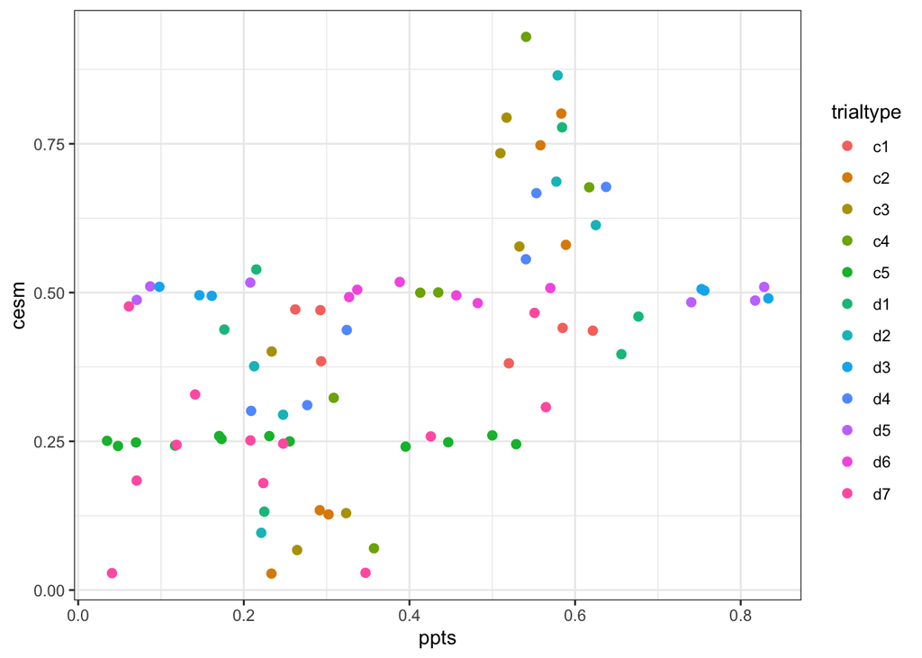

Then the important number is 0.482.

## Model predictions compared against participant data, split out by probability group

The first plot is probability group 1

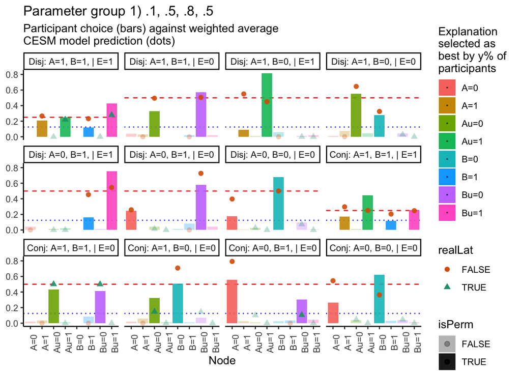

The second is probability group 2.

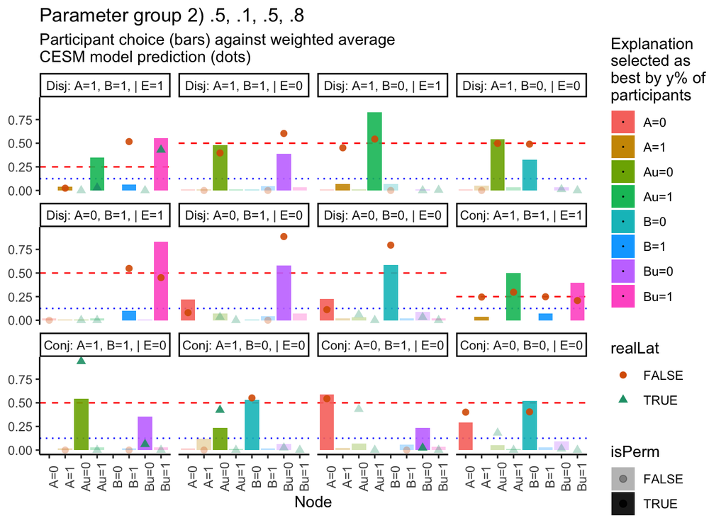

Now for probability group 3.

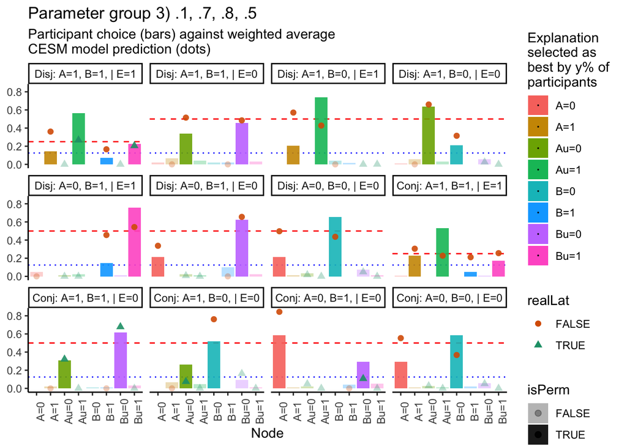

## NEW section for bringing in sensitivity

Now we have sensitivity as well as stability, both done on gridsearch, for each pairwise combo of them, there is a scatterplot of ppts against cesm, and a correlation for that.

These correlations can be visualised in a matrix, to quickly see what the best combo of stab and sens is.

So we need to calculate it for each. That might be in a different script. For now we can do it by sensitivity, as this doc is already per single s.

Let’s also split them out by probgroups…

### Parameter group 1) .1, .5, .8, .5.

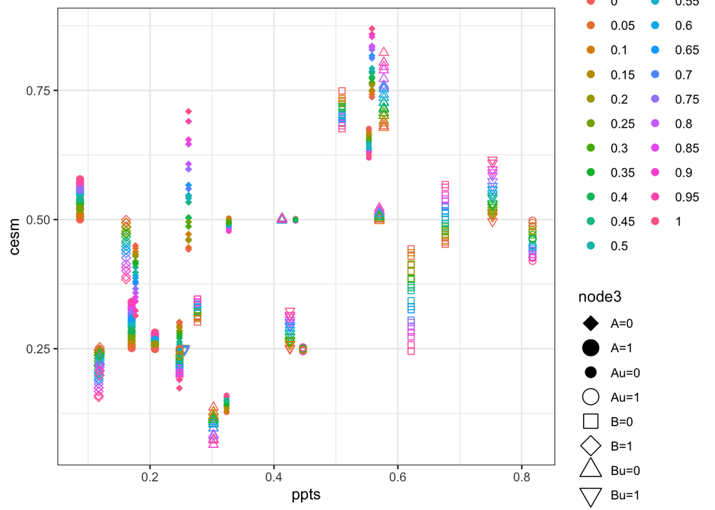

The correlation is 0.496.

### Parameter group 2) .5, .1, .5, .8.

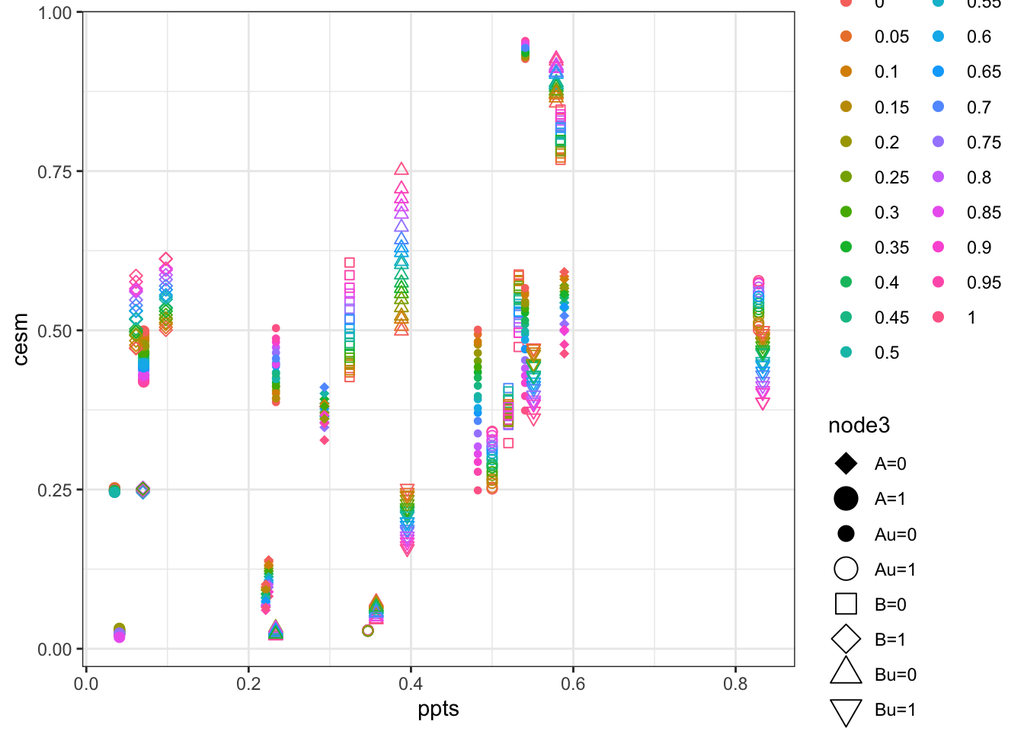

The correlation is 0.451.

### Parameter group 3) .1, .7, .8, .5.

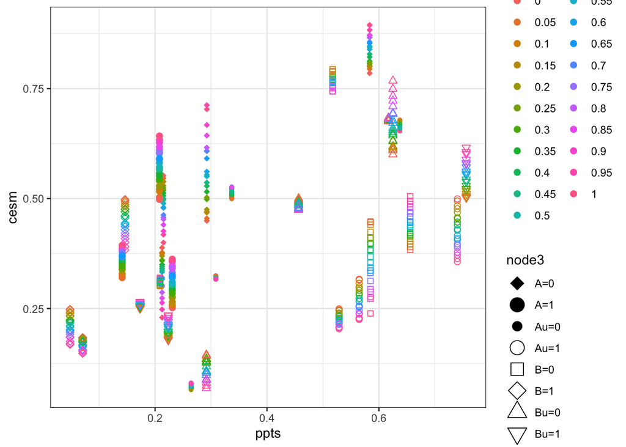

The correlation is 0.516.

Thus the average correlation across the three probability groups is 0.487666666666667